# Exploratory Data Analysis Report

## Exploratory Data analysis (EDA)

Analyzing the data sets to summarize their main characteristics of variables, often with visual graphs, without using a statistical model.

### 1. Overview of the data

Understanding the dimensions of the dataset, variable names, overall missing summary and data types of each variables

```r
# Overiview of the data
ExpData(data=data,type=1)
# Structure of the data
ExpData(data=data,type=2)
```

**Overview of the data**

| Descriptions | Obs |
| --- | --- |
| Sample size (Nrow) | 312 |
| No. of Variables (Ncol) | 27 |
| No. of Numeric Variables | 5 |
| No. of Factor Variables | 22 |
| No. of Text Variables | 0 |
| No. of Logical Variables | 0 |
| No. of Date Variables | 0 |
| No. of Zero variance Variables (Uniform) | 4 |
| %. of Variables having complete cases | 96.3% (26) |
| %. of Variables having <50% missing cases | 3.7% (1) |

[output cut: 2 more lines]

**Structure of the data**

| S.no | Variable Name | Variable Type | % of Missing | No. of Unique values |
| --- | --- | --- | --- | --- |
| 1 | country* | factor | 0 | 1 |
| 2 | year | integer | 0 | 26 |
| 3 | sex* | factor | 0 | 2 |
| 4 | age* | factor | 0 | 6 |
| 5 | suicides_no | integer | 0 | 233 |
| 6 | population | integer | 0 | 312 |
| 7 | suicides.100k.pop | numeric | 0 | 245 |
| 8 | country.year* | factor | 0 | 26 |
| 9 | gdp_for_year....* | factor | 0 | 26 |
| 10 | gdp_per_capita.... | integer | 0 | 26 |

[output cut: 17 more lines]

**Target variable**

Summary of continuous dependent variable

### 2. Summary of numerical variables

Summary statistics when dependent variable is Continuous **suicides_no**.

```r
ExpNumStat(data,by="A",gp=Target,Qnt=seq(0,1,0.1),MesofShape=2,Outlier=TRUE,round=2)
```

| Vname | Group | Note | TN | nNeg | nZero | nPos | NegInf | PosInf | NA_Value | Per_of_Missing | sum | min | max | mean | median | SD | CV | IQR | Skewness | Kurtosis | 0% | 10% | 20% | 30% | 40% | 50% | 60% | 70% | 80% | … |
| --- | --- | --- | --- | --- | --- | --- | --- | --- | --- | --- | --- | --- | --- | --- | --- | --- | --- | --- | --- | --- | --- | --- | --- | --- | --- | --- | --- | --- | --- | --- |
| gdp_per_capita.... | suicides_no | Cor b/w suicides_no | 312 | 0 | 0 | 312 | 0 | 0 | 0 | 0 | 2506440.00 | 3595.0 | 11663.00 | 8033.46 | 8264.00 | 2415.98 | 0.30 | 4164.00 | -0.20 | -1.16 | 3595.0 | 4505.00 | 5864.00 | 6518.00 | 7779.00 | 8264.00 | 8651.00 | 9991.00 | 10496.00 | … |
| population | suicides_no | Cor b/w suicides_no | 312 | 0 | 0 | 312 | 0 | 0 | 0 | 0 | 2427316559.00 | 489000.0 | 15940497.00 | 7779860.77 | 9413673.00 | 3997988.94 | 0.51 | 6458690.00 | -0.48 | -0.96 | 489000.0 | 1179337.00 | 3378036.80 | 5614552.60 | 7592851.60 | 9413673.00 | 9978756.80 | 10439393.30 | 11240771.40 | … |
| suicides.100k.pop | suicides_no | Cor b/w suicides_no | 312 | 0 | 0 | 312 | 0 | 0 | 0 | 0 | 1535.37 | 0.1 | 19.25 | 4.92 | 2.07 | 4.78 | 0.97 | 8.02 | 0.83 | -0.40 | 0.1 | 0.54 | 0.87 | 1.08 | 1.35 | 2.07 | 6.18 | 8.59 | 9.35 | … |
| suicides_no | suicides_no | Cor b/w suicides_no | 312 | 0 | 0 | 312 | 0 | 0 | 0 | 0 | 102612.00 | 4.0 | 1560.00 | 328.88 | 158.00 | 366.90 | 1.12 | 412.25 | 1.36 | 0.84 | 4.0 | 27.10 | 55.40 | 85.60 | 111.00 | 158.00 | 236.40 | 386.40 | 618.40 | … |
| year | suicides_no | Cor b/w suicides_no | 312 | 0 | 0 | 312 | 0 | 0 | 0 | 0 | 624780.00 | 1990.0 | 2015.00 | 2002.50 | 2002.50 | 7.51 | 0.00 | 13.00 | 0.00 | -1.20 | 1990.0 | 1992.00 | 1995.00 | 1997.00 | 2000.00 | 2002.50 | 2005.00 | 2008.00 | 2010.00 | … |

### 3. Distributions of numerical variables

Graphical representation of all numeric features, used below types of plots to explore the data

- Quantile-quantile plot (Univariate)
- Density plot (Univariate)
- Scatter plot (Bivariate)

#### Quantile-quantile plot for Numerical variables - Univariate

Quantile-quantile plot for all Numerical variables

```r
ExpOutQQ(data,nlim=4,fname=NULL,Page=c(2,2),sample=sn)
```

```
## $`0`
```

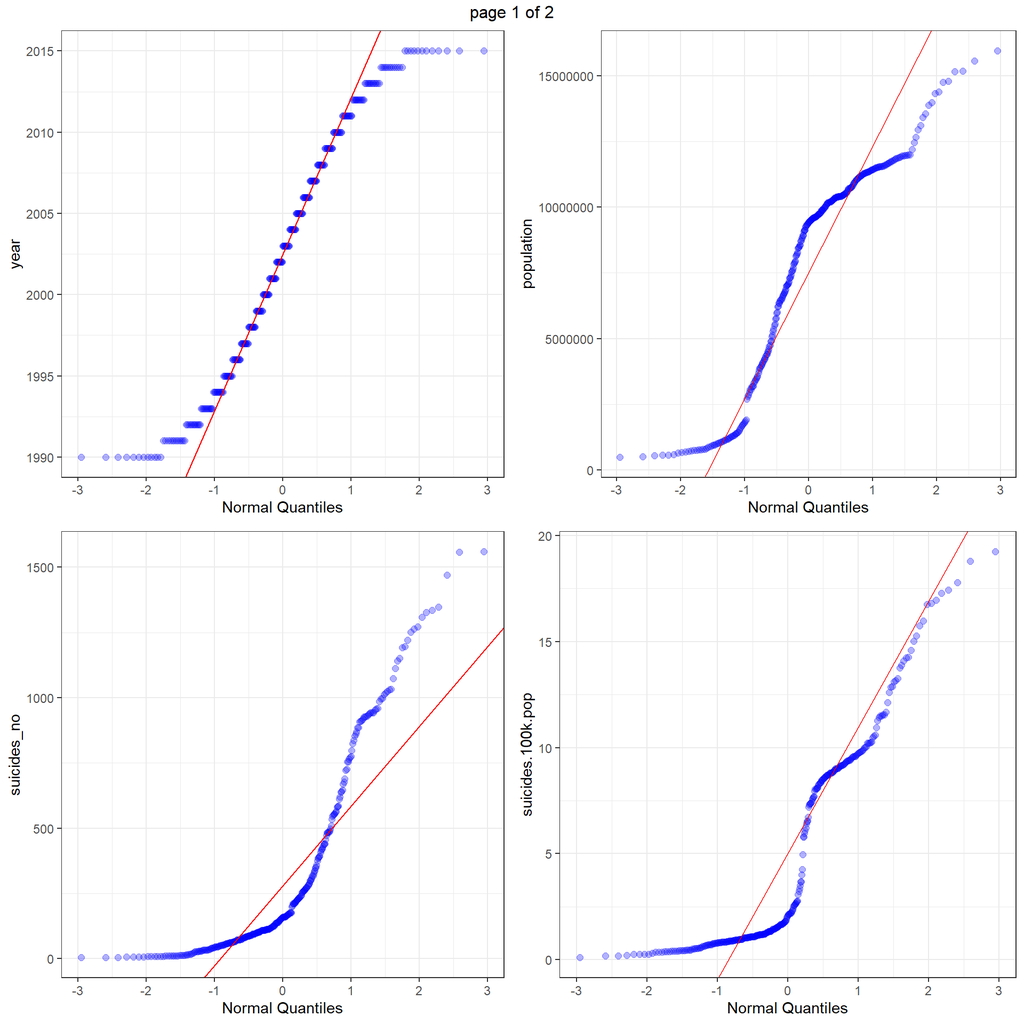

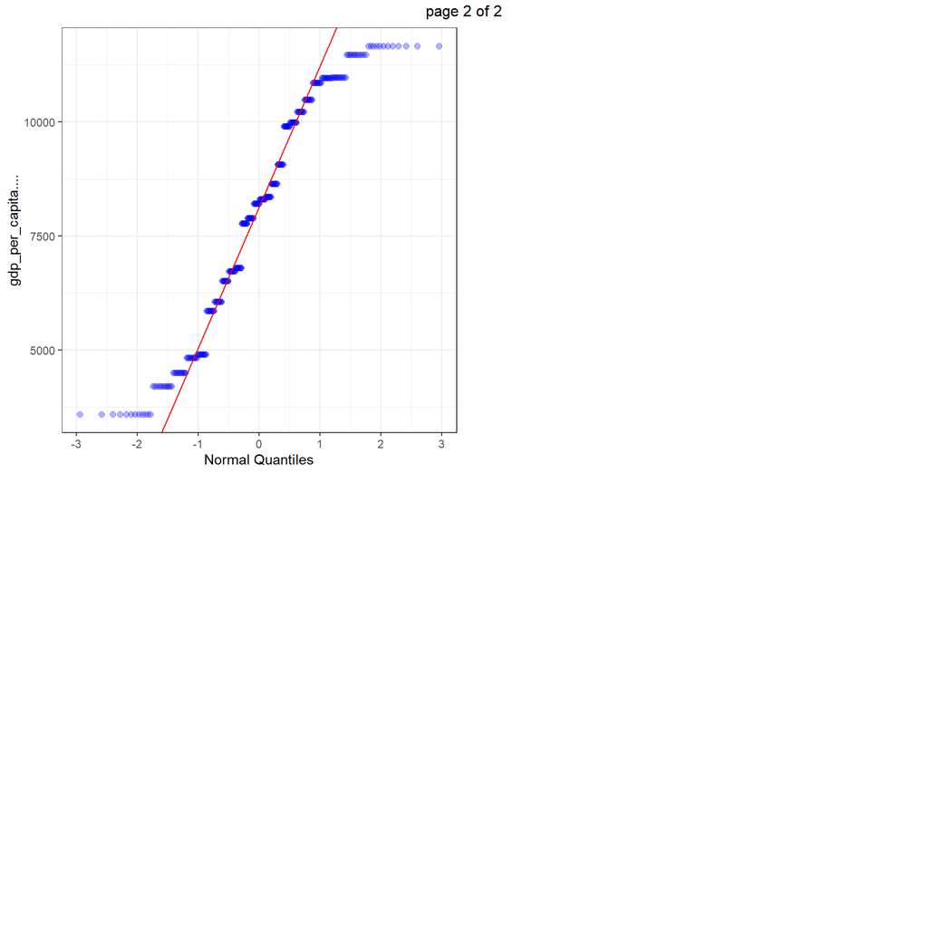

#### Density plots for numerical variables - Univariate

Density plot for all numerical variables

```
## $`0`
```

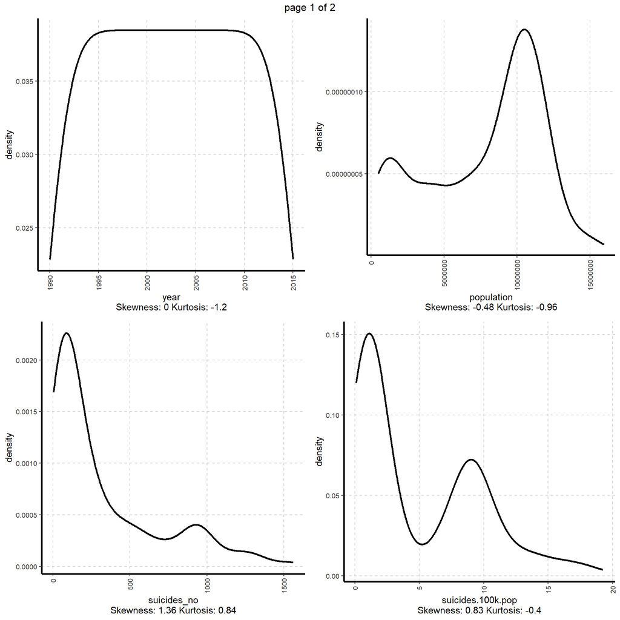

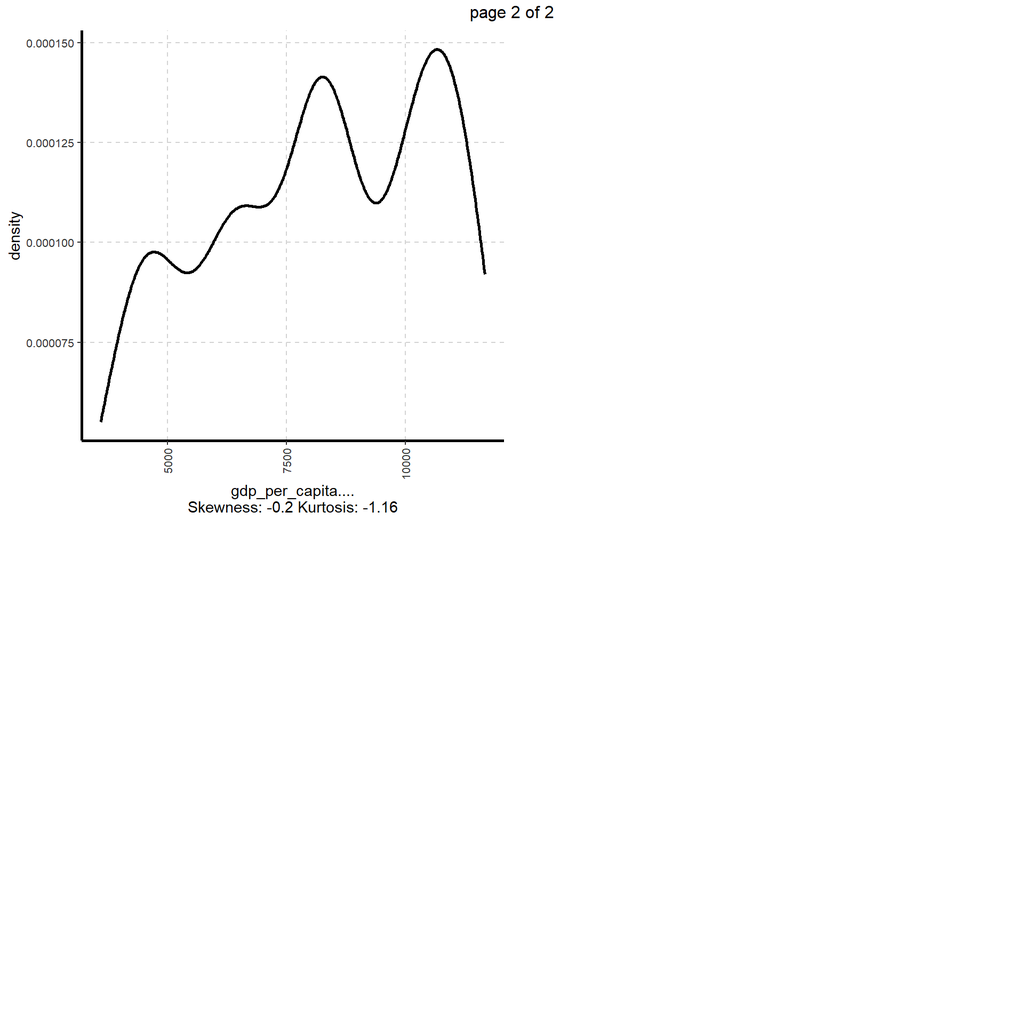

```r
ExpNumViz(data,target=NULL,nlim=5,fname=NULL,col=NULL,theme=theme,Page=c(2,2),sample=sn)
```

#### Scatter plot for all Numeric variables

```
## $`0`
```

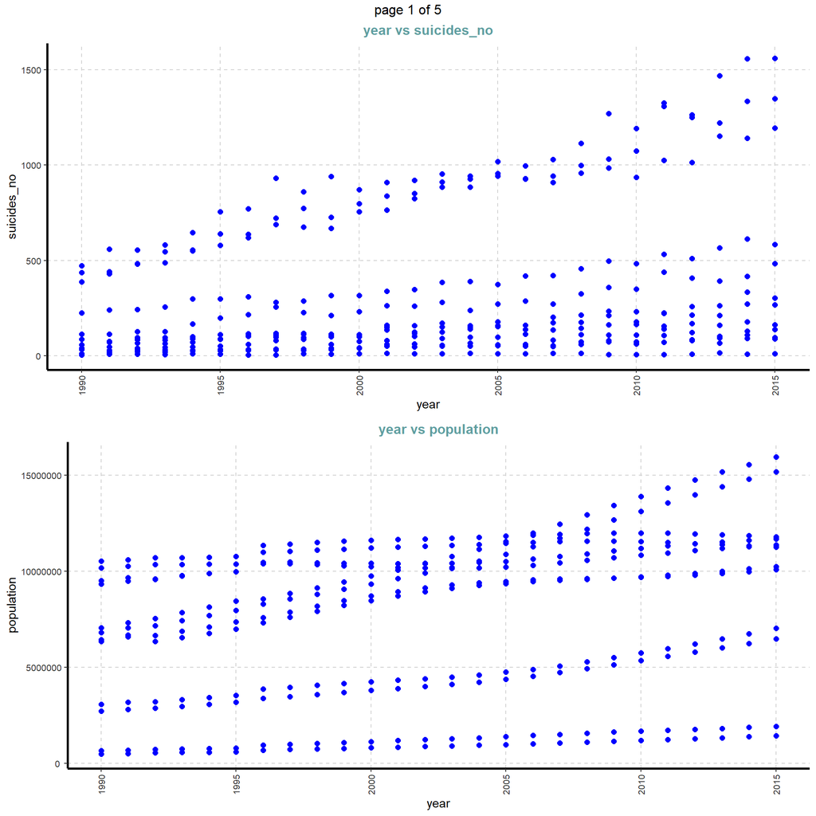

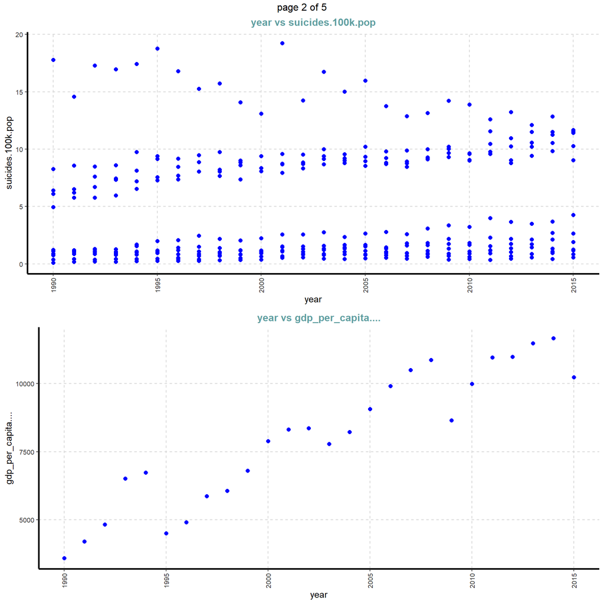

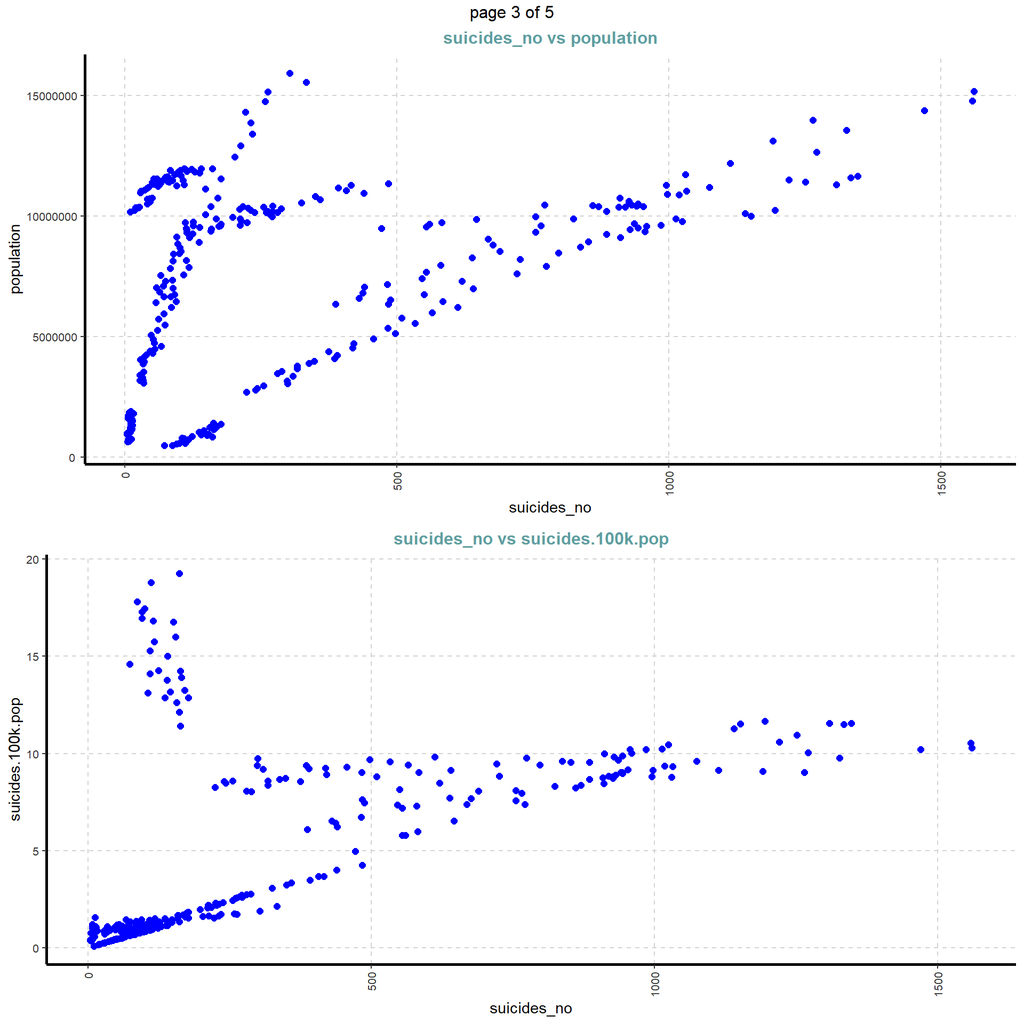

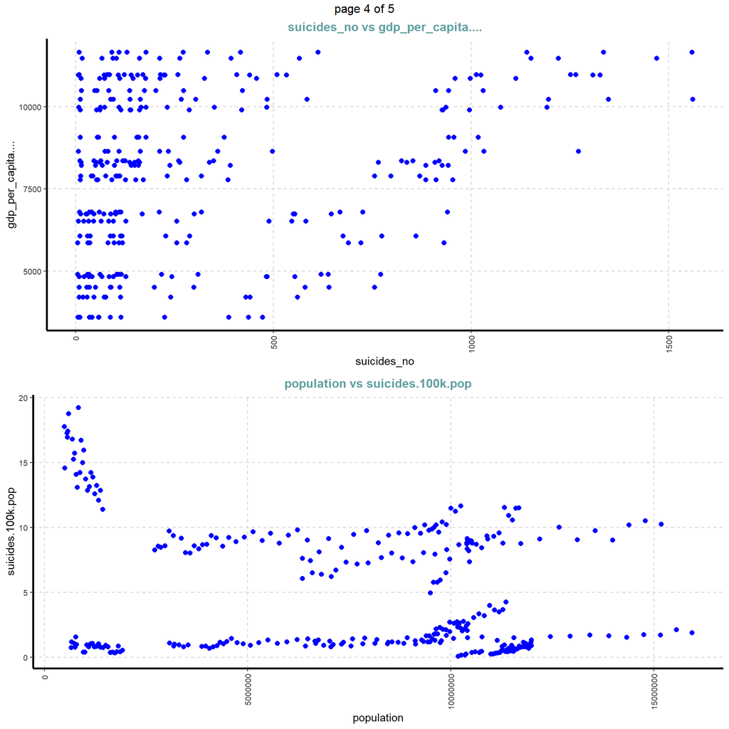

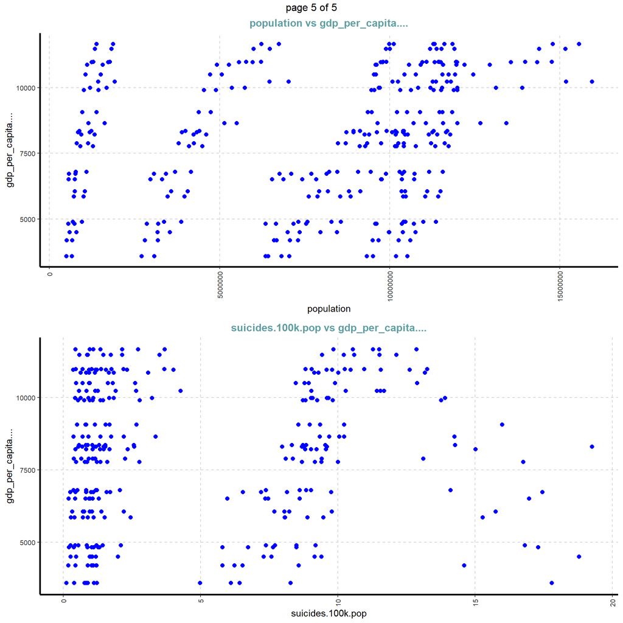

```r
ExpNumViz(data,target=NULL,nlim=5,Page=c(2,1),theme=theme,sample=sn,scatter=TRUE)
```

#### Correlation between dependent variable vs Independent variables

Dependent variable is **suicides_no** (continuous).

```
## $`0`
```

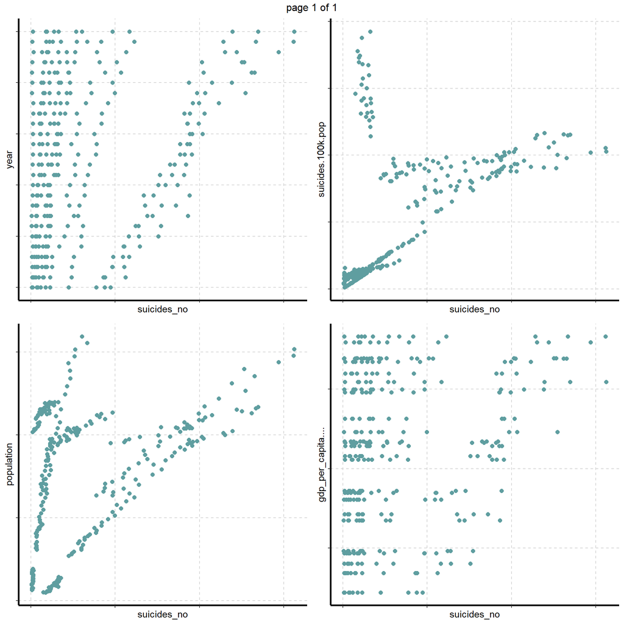

```r
ExpNumViz(data,target=Target,nlim=5,fname=NULL,col=NULL,theme=theme,Page=c(2,2),sample=sn)
```

```r
ExpNumStat(data,by="GA",gp=Target,Qnt=NULL,MesofShape=2,Outlier=FALSE,round=2,dcast=T,val="cor")
```

| Stat | Vname | suicides_no |
| --- | --- | --- |
| cor | gdp_per_capita.... | 0.25 |
| cor | population | 0.39 |
| cor | suicides.100k.pop | 0.57 |
| cor | suicides_no | 1.00 |
| cor | year | 0.28 |

### 4. Summary of categorical variables

Summary of categorical variables

- frequency for all categorical independent variables

```r
ExpCTable(data,margin=1,clim=10,nlim=NULL,round=2,bin=NULL,per=T)
```

| Variable | Valid | Frequency | Percent | CumPercent |
| --- | --- | --- | --- | --- |
| sex | female | 156 | 50.00 | 50.00 |
| sex | male | 156 | 50.00 | 100.00 |
| sex | TOTAL | 312 | NA | NA |
| age | 15-24 years | 52 | 16.67 | 16.67 |
| age | 25-34 years | 52 | 16.67 | 33.34 |
| age | 35-54 years | 52 | 16.67 | 50.01 |
| age | 5-14 years | 52 | 16.67 | 66.68 |
| age | 55-74 years | 52 | 16.67 | 83.35 |
| age | 75+ years | 52 | 16.67 | 100.02 |
| age | TOTAL | 312 | NA | NA |

[output cut: 7 more lines]

- frequency for all categorical independent variables by descretized **suicides_no**

```r
##bin=4, descretized 4 categories based on quantiles
ExpCTable(data,Target=Target,margin=1,clim=10,nlim=NULL,round=2,bin=4,per=T)
```

| VARIABLE | CATEGORY | Number | suicides_no:(2.44,393] | suicides_no:(393,782] | suicides_no:(782,1.17e+03] | suicides_no:(1.17e+03,1.56e+03] | TOTAL |
| --- | --- | --- | --- | --- | --- | --- | --- |
| sex | female | nn | 152.00 | 4.00 | 0.00 | 0.00 | 156.00 |
| sex | male | nn | 69.00 | 38.00 | 36.00 | 13.00 | 156.00 |
| sex | TOTAL | nn | 221.00 | 42.00 | 36.00 | 13.00 | 312.00 |
| sex | female | % | 68.78 | 9.52 | 0.00 | 0.00 | 50.00 |
| sex | male | % | 31.22 | 90.48 | 100.00 | 100.00 | 50.00 |
| sex | TOTAL | % | 100.00 | 100.00 | 100.00 | 100.00 | 100.00 |
| age | 15-24 years | nn | 22.00 | 11.00 | 14.00 | 5.00 | 52.00 |
| age | 25-34 years | nn | 27.00 | 9.00 | 15.00 | 1.00 | 52.00 |
| age | 35-54 years | nn | 26.00 | 12.00 | 7.00 | 7.00 | 52.00 |
| age | 5-14 years | nn | 52.00 | 0.00 | 0.00 | 0.00 | 52.00 |

[output cut: 24 more lines]

### 5. Distributions of Categorical variables

Graphical representation of all Categorical variables

- Bar plot (Univariate)

Bar plot with vertical or horizontal bars for all categorical variables

```
## $`0`
```

[figure not shown]

```r
ExpCatViz(data,target=NULL,clim=10,margin=2,theme=theme,Page = c(2,2),sample=sc)
```